# Exercícios da Lista 3

Tomás Ferranti

8 Abril 2020

### Capítulo 2, Edição 2010: Ex 9

## Ex. 9

A MB Indústria e Comércio, desejando melhorar o nível de seus funcionários em cargos de chefia, montou um curso experimental e indicou 2: funcionários para a primeira turma. Os dados referentes à seção a que pertencem, notas e graus obtidos no curso estão na tabela a seguir. Como havia dúvidas quanto à adoção de um único critério de avaliação, cada instrutor adotou seu próprio sistema de aferição. Usando dados daquela tabela, responda às questões:

```r
matrizDeDados <- t(matrix(c(1,"P" ,8.0, 9.0, 8.6, 9.0, "B" ,"A" ,9.0 ,8.5,
2, "P", 8.0, 9.0 ,7.0 ,9.0 ,"B" ,"C" ,6.5 ,8.0,
3, "P", 8.0 ,9.0 ,8.0 ,8.0 ,"D" ,"B" ,9.0 ,8.5,
4, "P", 6.0 ,9.0 ,8.6 ,8.0 ,"D" ,"C" ,6.0 ,8.5,
5, "P", 8.0 ,9.0 ,8.0 ,9.0 ,"A" ,"A" ,6.5 ,9.0,
6, "P", 8.0 ,9.0 ,8.5 ,10.0 ,"B" ,"A" ,6.5 ,9.5,
7, "P", 8.0 ,9.0 ,8.2 ,8.0 ,"D" ,"C" ,9.0 ,7.0,
8, "T", 10.0 ,9.0 ,7.5 ,8.0 ,"B" ,"C" ,6.0 ,8.5,
9, "T", 8.0 ,9.0 ,9.4 ,9.0 ,"B" ,"B" ,10.0 ,8.0,
10, "T", 10.0 ,9.0 ,7.9 ,8.0 ,"B" ,"C" ,9.0 ,7.5,
11, "T", 8.0 ,9.0 ,8.6 ,10.0 ,"C" ,"B" ,10.0 ,8.5,
12, "T", 8.0 ,9.0 ,8.3 ,7.0 ,"D" ,"B" ,6.5 ,8.0,
13, "T", 6.0 ,9.0 ,7.0 ,7.0 ,"B" ,"C" ,6.0 ,8.5,
14, "T", 10.0 ,9.0 ,8.6 ,9.0 ,"A" ,"B" ,10.0 ,7.5,
15, "V", 8.0 ,9.0 ,8.6 ,9.0 ,"C" ,"B" ,10.0 ,7.0,
16, "V", 8.0 ,9.0 ,9.5 ,7.0 ,"A" ,"A" ,9.0 ,7.5,
17, "V", 8.0 ,9.0 ,6.3 ,8.0 ,"D" ,"C" ,10.0 ,7.5,
18, "V", 6.0 ,9.0 ,7.6 ,9.0 ,"C" ,"C" ,6.0 ,8.5,
19, "V", 6.0 ,9.0 ,6.8 ,4.0 ,"D" ,"C" ,6.0 ,9.5,
20, "V", 6.0 ,9.0 ,7.5 ,7.0 ,"C" ,"B" ,6.0 ,8.5,
21, "V", 8.0 ,9.0 ,7.7 ,7.0 ,"D" ,"B" ,6.5 ,8.0,
22, "V", 6.0 ,9.0 ,8.7 ,8.0 ,"C" ,"A" ,6.0 ,9.0,
23, "V", 8.0 ,9.0 ,7.3 ,10.0 ,"C" ,"C" ,9.0 ,7.0,
24, "V", 8.0 ,9.0 ,8.5 ,9.0 ,"A" ,"A" ,6.5 ,9.0,
25, "V", 8.0 ,9.0 ,7.0 ,9.0 ,"B" ,"A" ,9.0 ,8.5),nrow=10,ncol=25))
colnames(matrizDeDados) <- c("Func","Secao","Administr","Direito","Redacao","Estatist","Ingles","Metodologia","Politica","Economia")
data.ex9 <- data.frame(matrizDeDados)
data.ex9
```

```
##    Func Secao Administr Direito Redacao Estatist Ingles Metodologia Politica
## 1     1     P         8       9     8.6        9      B           A        9
## 2     2     P         8       9       7        9      B           C      6.5
## 3     3     P         8       9       8        8      D           B        9
## 4     4     P         6       9     8.6        8      D           C        6
## 5     5     P         8       9       8        9      A           A      6.5
## 6     6     P         8       9     8.5       10      B           A      6.5
## 7     7     P         8       9     8.2        8      D           C        9
## 8     8     T        10       9     7.5        8      B           C        6
## 9     9     T         8       9     9.4        9      B           B       10
## 10   10     T        10       9     7.9        8      B           C        9
## 11   11     T         8       9     8.6       10      C           B       10
## 12   12     T         8       9     8.3        7      D           B      6.5
## 13   13     T         6       9       7        7      B           C        6
## 14   14     T        10       9     8.6        9      A           B       10
```

[output cut: 37 more lines]

1. Após observar atentamente cada variável, e com o intuito de resumi-las, como você identificaria (qualitativa ordinal ou nominal e quantitativa discreta ou contínua) cada uma das $9$ variáveis listadas?

**Respondido na Lista 1.**

2. Compare e indique as diferenças existentes entre as distribuições das variáveis Direito, Política e Estatística.

**Respondido na Lista 1.**

3. Construa o histograma para as notas da variável Redação.

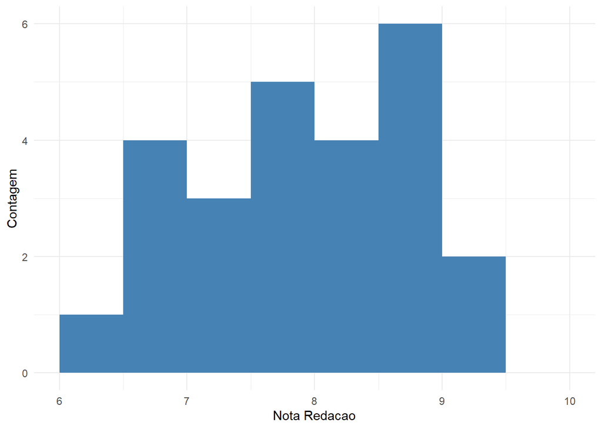

```r
data.ex9$Redacao <- as.numeric(paste(data.ex9$Redacao))
ggplot(data.ex9,aes(x=Redacao)) + geom_histogram(identity=TRUE,fill="steelblue",breaks=seq(6,10,0.5)) + theme_minimal() + xlab("Nota Redacao") + ylab("Contagem")
```

4. Construa a distribuição de freqüências da variável Metodologia e faça um gráfico para indicar essa distribuição.

```r
data.ex9d <- table(paste(data.ex9$Metodologia))
data.ex9d
```

```
##
##  A  B  C
##  7  8 10
```

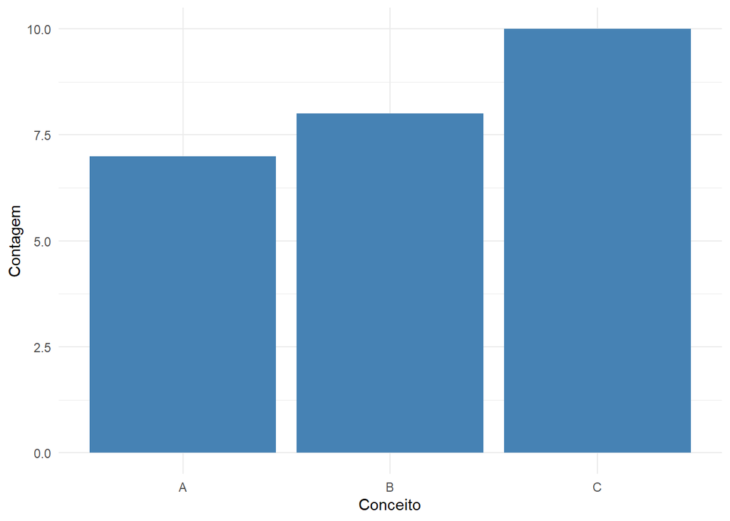

```r
ggplot(data.frame(data.ex9d), aes(x=Var1,y=Freq)) + geom_bar(stat='identity',fill="steelblue") + theme_minimal() + xlab("Conceito") + ylab("Contagem")
```

5. Sorteado ao acaso um dos 2: funcionários, qual a probabilidade de que ele tenha obtido grau A em Metodologia?

**Respondido na Lista 1.**

6. Se, em vez de um, sorteássemos dois, a probabilidade de que ambos tivessem tido A em Metodologia é maior ou menor do que a resposta dada em (e)?

**Respondido na Lista 1.**

7. Como é o aproveitamento dos funcionários na disciplina Estatística, segundo a seção a que eles pertencem?

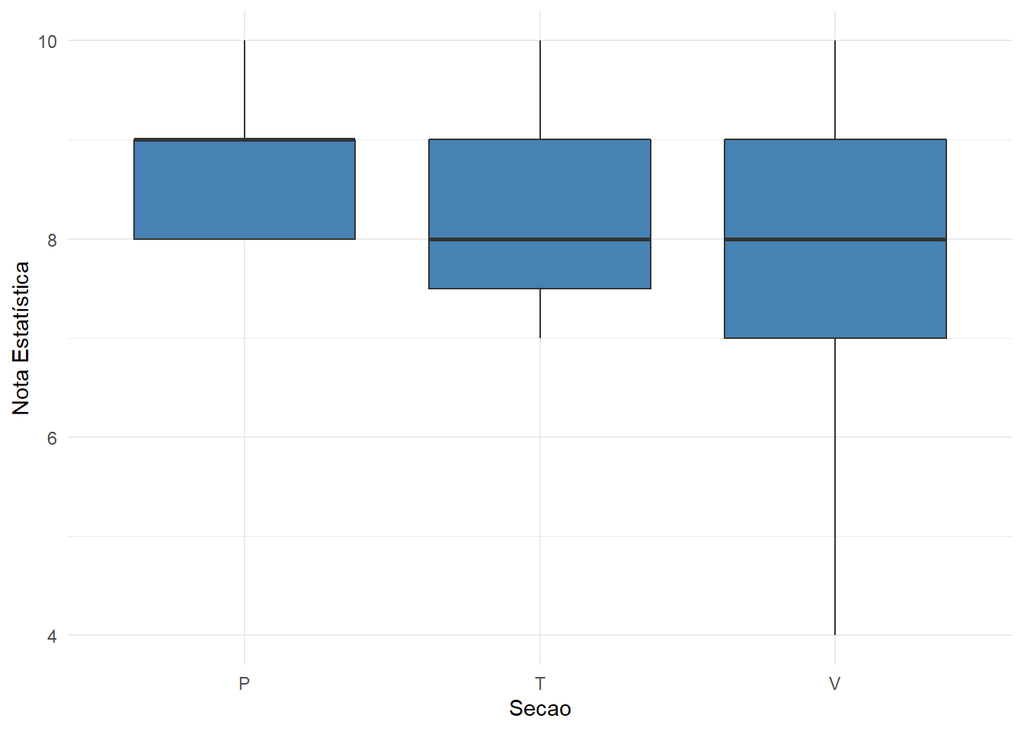

```r
library(ggplot2)
newData.ex9 <- data.ex9
newData.ex9$Estatist <- as.numeric(paste(newData.ex9$Estatist))
ggplot(newData.ex9,aes(x=Secao,y=Estatist)) + geom_boxplot(fill="steelblue") + ylab("Nota Estatística") + theme_minimal()
```

### Capítulo 3, Edição 2010: Ex 29 a 33, 38

## Ex. 29

Para se estudar o desempenho de duas corretoras de ações, selecionou-se de cada uma delas, amostras aleatórias das ações negociadas. Para cada ação selecionada, computou-se a porcentagem de lucro apresentada durante um período fixado de tempo. Os dados estão a seguir:

```r
corretora.A <- data.frame(periodo_1 = c(45, 62, 38, 55, 54, 65), periodo_2 = c(60, 55, 48, 56, 59, 55), periodo_3 = c(54, 70, 64, 55, 48, 60))
quant <- c(0.25,0.5,0.75)

corretora.A
```

```
##   periodo_1 periodo_2 periodo_3
## 1        45        60        54
## 2        62        55        70
## 3        38        48        64
## 4        55        56        55
## 5        54        59        48
## 6        65        55        60
```

```r
corretora.B <- data.frame(periodo_1 = c(57, 50, 59, 61, 57, 55, 59), periodo_2 = c(55, 52, 55, 52, 57, 58, 51), periodo_3 = c(58, 59, 56, 53, 50, 54, 56))

corretora.B
```

```
##   periodo_1 periodo_2 periodo_3
## 1        57        55        58
## 2        50        52        59
## 3        59        55        56
## 4        61        52        53
## 5        57        57        50
## 6        55        58        54
## 7        59        51        56
```

Que tipo de informação revelam esses dados? (Sugestão: Observar os quantis empíricos)

```r
quant.A <- data.frame(periodo_1.A = quantile(corretora.A$periodo_1, probs = quant), periodo_2.A = quantile(corretora.A$periodo_2, probs = quant), periodo_3.A = quantile(corretora.A$periodo_3, probs = quant))

quant.B <- data.frame(periodo_1.B = quantile(corretora.B$periodo_1, probs = quant), periodo_2.B = quantile(corretora.B$periodo_2, probs = quant), periodo_3.B = quantile(corretora.B$periodo_3, probs = quant))

quants = cbind(quant.A,quant.B)
quants
```

```
##     periodo_1.A periodo_2.A periodo_3.A periodo_1.B periodo_2.B periodo_3.B
## 25%       47.25       55.00       54.25          56          52        53.5
## 50%       54.50       55.50       57.50          57          55        56.0
## 75%       60.25       58.25       63.00          59          56        57.0
```

Podemos observar que a corretora A apresenta valores baixos comparados à corretora B no primeiro período, mas com relação aos outros dois períodos ela têm uma performance melhor. Além disso, os valores possuem uma variação mais alta na corretora A do que na corretora B.

## Ex. 30

Para verificar a homogeneidade das duas populações do problema anterior, um estatístico sugeriu que se usasse o quociente
$$F = \frac{var(X/A)}{var(X/B)}$$
sendo $var(X/A)$ a variância de X para a corretora A; $X =$ porcentagem de lucro. No entanto, o profissional não disse qual decisão tomar baseado nesse valor. Que regra de decisão voce adotaria para dizer se são homogêneas ou não?

```r
data.A <- c(corretora.A$periodo_1,corretora.A$periodo_2,corretora.A$periodo_3)
varX.A <- var(data.A)*(length(data.A)-1)/length(data.A)

data.B <- c(corretora.B$periodo_1,corretora.B$periodo_2,corretora.B$periodo_3)
varX.B <- var(data.B)*(length(data.B)-1)/length(data.B)

Fvalue <- varX.A/varX.B
Fvalue
```

```
## [1] 5.809534
```

Como o valor de $F$ é acima de $5$, isso indica que a variância dos dados da corretora $A$ é $5$ vezes maior que o da $B$, indicando que elas não são homogêneas.

## Ex. 31

Faça um gráfico *boxplot* para cada uma das corretoras e compare os dois conjuntos de dados a partir dos gráficos.

```r
#ggplot(dados37,aes(x=regiao,y=total)) + geom_boxplot() + scale_y_continuous(labels = scales::comma)
newCorretora.A <- data.frame(melt(corretora.A))
```

```
## Using  as id variables
```

```r
grafico.A <- ggplot(newCorretora.A,aes(x=variable,y=value)) + geom_boxplot(fill="steelblue") + xlab("Período") + ylab("Porcentagem de Lucro") + theme_minimal()
newCorretora.B <- data.frame(melt(corretora.B))
```

```
## Using  as id variables
```

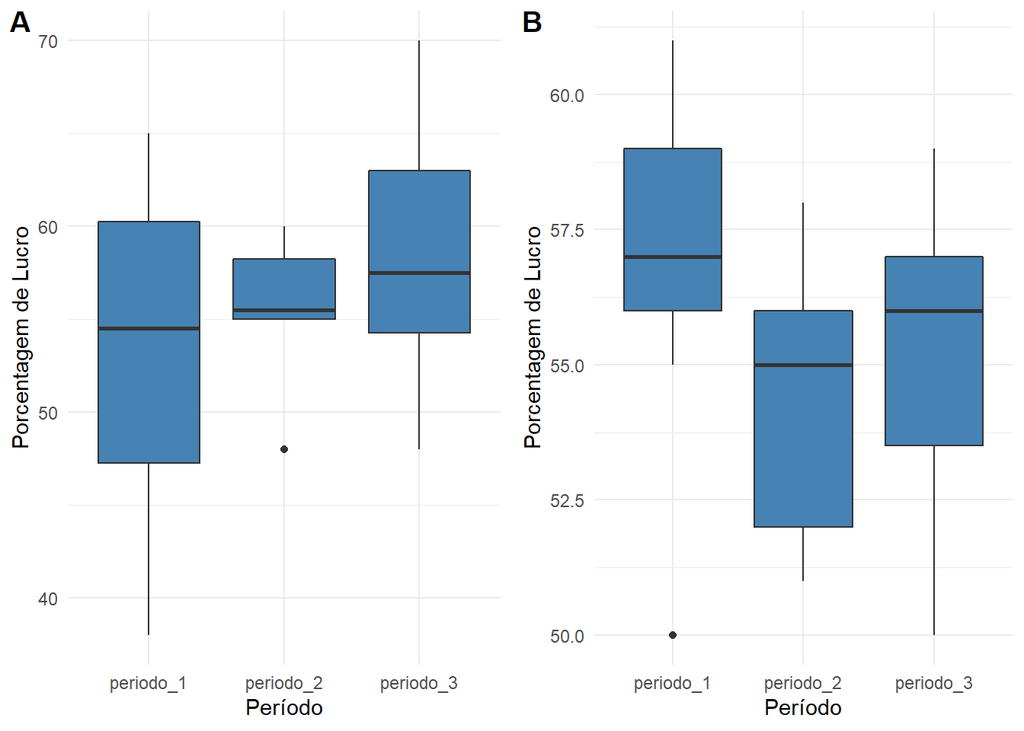

```r
grafico.B <- ggplot(newCorretora.B,aes(x=variable,y=value)) + geom_boxplot(fill="steelblue") + xlab("Período") + ylab("Porcentagem de Lucro") + theme_minimal()
graficoEx30 <- ggarrange(grafico.A, grafico.B, labels = c("A", "B", "C"), ncol = 2, nrow = 1)
graficoEx30
```

## Ex. 32

Para decidir se o desempenho das duas corretoras são semelhantes ou não, adotou-se o seguinte teste:

$$t = \frac{\bar{x_A} - \bar{x_B}}{S^2*\sqrt{1/{n_A} + 1/{n_B}}}$$
$$S^2 = \frac{(n_A -1)var(X/A) + (n_B -1)var(X/B)}{n_A + n_B - 2}$$
Sendo $n_A$ e $n_B$ o número de ações selecionadas das corretoras $A$ e $B$ respectivamente.

Caso $|t| < 2$, os desempenhos são semelhantes, caso contrário, são diferentes. Qual seria a sua conclusão?

```r
n.A <- length(data.A)
n.B <- length(data.B)
x.A <- mean(data.A)
x.B <- mean(data.B)
S2 <- ((n.A-1)*varX.A+(n.B-1)*varX.B)/(n.A+n.B-2)
t <- (x.A-x.B)/(S2*(1/n.A+1/n.B)^(1/2))
t
```

```
## [1] 0.02973606
```

Como $|t| < 2$, os desempenhos são semelhantes.

## Ex. 33

Um órgão do governo do estado está interessado em determinar padrões sobre o investimento em educação, por habitante, realizado pelas prefeituras. De um levantamento de dez cidades, foram obtidos os valores (codificados) da tabela abaixo:

```r
invest <- data.frame(cidade = c("A","B","C","D","E","F","G","H","I","J"), investimento = c(20,16,14,8,19,15,14,16,19,18))
invest
```

```
##    cidade investimento
## 1       A           20
## 2       B           16
## 3       C           14
## 4       D            8
## 5       E           19
## 6       F           15
## 7       G           14
## 8       H           16
## 9       I           19
## 10      J           18
```

Nesse caso, será considerado como investimento básico a média final das observações, calculada da seguinte maneira:

1. Obtém-se uma média inicial.
2. Eliminam-se do conjunto aquelas observações que forem superiores à média inicial mais duas vezes o desvio padrão, ou inferiores à média inicial menos duas vezes o desvio padrão.
3. Calcula-se a média final com o novo conjunto de observações. Qual o investimento básico que você daria como resposta?

Observação: O procedimento do item 2 tem a finalidade de eliminar do conjunto a cidade cujo investimento é muito diferente dos demais.

```r
medIni <- mean(invest$investimento)
desvPad <- sum((invest$investimento-medIni)^2/(length(invest$investimento)))^(1/2)
newInvest <- invest[(invest$investimento>medIni-2*desvPad),]
newInvest <- newInvest[(newInvest$investimento<medIni+2*desvPad),]
medFin <- mean(newInvest$investimento)
medFin
```

```
## [1] 16.77778
```

O investimento básico seria $16.77778$.

## Ex. 38

No Problema 9, do Capítulo 2, temos os resultados de 25 funcionários em vários exames a que se submeteram. Sabe-se agora que os critérios adotados em cada exame não são comparáveis, por isso decidiu-se usar o desempenho relativo em cada exame. Essa medida será obtida do seguinte modo: (I) Para cada exame serão calculados a média e o desvio padrão. (II) A nota X de cada aluno será padronizada.

1. Interprete o significado de Z.

$Z$ é a variável padronizada à uma certa escala de medida, também conhecida como a distribuição normal padrão.

2. Calcule as notas padronizadas dos funcionários para o exame de Estatística.

```r
data.ex9$Estatist <- as.numeric(paste(data.ex9$Estatist))
media.ex38b <- mean(data.ex9$Estatist)
desvpad.ex38b <- (((length(data.ex9$Estatist)-1)/length(data.ex9$Estatist))*var(data.ex9$Estatist))^(1/2)
z.ex38 <- (data.ex9$Estatist-media.ex38b)/desvpad.ex38b
z.ex38
```

```
##  [1]  0.5966706  0.5966706 -0.1884223 -0.1884223  0.5966706  1.3817634
##  [7] -0.1884223 -0.1884223  0.5966706 -0.1884223  1.3817634 -0.9735152
## [13] -0.9735152  0.5966706  0.5966706 -0.9735152 -0.1884223  0.5966706
## [19] -3.3287938 -0.9735152 -0.9735152 -0.1884223  1.3817634  0.5966706
## [25]  0.5966706
```

3. Com os resultados obtidos em (b), calcule a média e desvio padrão de Z.

```r
media.ex38c <- mean(z.ex38)
desvpad.ex38c <- (((length(z.ex38)-1)/length(z.ex38))*var(z.ex38))^(1/2)
data.ex38c <- c(media.ex38c,desvpad.ex38c)
names(data.ex38c) <- c("Média","Desvio Padrão")
data.ex38c
```

```
##         Média Desvio Padrão
## -1.731688e-16  1.000000e+00
```

4. Se alguma das notas padronizadas estiver acima de 2dp(Z) ou abaixo de -2dp(Z), esse funcionário deve ser considerado um caso atípico. Existe algum nessa situação?

```r
data.outlier38 <- c(z.ex38[z.ex38 < (-2)],z.ex38[z.ex38 > (2)])
data.outlier38
```

```
## [1] -3.328794
```

5. O funcionário 1 obteve 9,0 em Direito, em Estatística e em Política. Em que disciplina o seu desempenho relativo foi melhor?

```r
data.ex38e <- data.ex9
data.ex38e$Direito <- as.numeric(paste(data.ex38e$Direito))
data.ex38e$Direito <- (data.ex38e$Direito - mean(data.ex38e$Direito))
#data.ex38e$Direito <- data.ex38e$Direito/(((length(data.ex38e$Direito)-1)/length(data.ex38e$Direito))*var(data.ex38e$Direito))^(1/2)

data.ex38e$Politica <- as.numeric(paste(data.ex38e$Politica))
data.ex38e$Politica <- (data.ex38e$Politica - mean(data.ex38e$Politica))
data.ex38e$Politica <- data.ex38e$Politica/(((length(data.ex38e$Politica)-1)/length(data.ex38e$Politica))*var(data.ex38e$Politica))^(1/2)

notaPadDir <- data.ex38e$Direito[1]
notaPadEst <- z.ex38[1]
notaPadPol <- data.ex38e$Politica[1]
notas <- c(notaPadDir,notaPadEst,notaPadPol)
names(notas) <- c("Direito","Estatística","Política")
notas
```

```
##     Direito Estatística    Política
##   0.0000000   0.5966706   0.7571116
```

Política foi a disciplina com seu maior desempenho relativo.

### Capítulo 4, Edição 2010: Ex 19, 20, 22, 29 e 30

## Ex. 19

Uma amostra de 200 habitantes de uma cidade foi escolhida para declarar sua opinião sobre um certo projeto governamental. O resultado foi o seguinte:

```r
data.ex19 <- matrix(c(30,60,90,35,25,60,35,15,50,100,100,200),nrow = 3, ncol = 4)
colnames(data.ex19) <- c("Urbano","Suburbano","Rural","Total")
rownames(data.ex19) <- c("A favor","Contra","Total")
data.ex19
```

```
##         Urbano Suburbano Rural Total
## A favor     30        35    35   100
## Contra      60        25    15   100
## Total       90        60    50   200
```

1. Calcule as proporções em relação ao total das colunas.

```r
data.ex19per <- data.ex19
for(i in 1:ncol(data.ex19)){
  data.ex19per[,i] <- data.ex19[,i]/sum(data.ex19[1:2,i])
}
data.ex19per
```

```
##            Urbano Suburbano Rural Total
## A favor 0.3333333 0.5833333   0.7   0.5
## Contra  0.6666667 0.4166667   0.3   0.5
## Total   1.0000000 1.0000000   1.0   1.0
```

2. Você diria que a opinião independe do local de residência?

Não, devido à grande diferença nos valores percentuais.

3. Encontre uma medida de dependência entre as variações.

```r
chisquare <- chisq.test(data.ex19[1:2,1:3])$statistic
C.ex19 <- (chisquare/(chisquare+data.ex19[3,4]))^(1/2)
names(C.ex19) <- "C"
C.ex19
```

```
##        C
## 0.299215
```

## Ex. 20

Com base na tabela abaixo, você concluiria que o tipo de atividade está relacionado ao fato de as embarcações serem de propriedade estatal ou particular? Encontre uma medida de dependência entre as variáveis.

```r
data.ex20 <- matrix(c(5,92,141,231,51,48),nrow = 2, ncol = 3)
colnames(data.ex20) <- c("Costeira","Fluvial","Internacional")
rownames(data.ex20) <- c("Estatal","Particular")
data.ex20
```

```
##            Costeira Fluvial Internacional
## Estatal           5     141            51
## Particular       92     231            48
```

```r
chisquare <- chisq.test(data.ex20[1:2,1:3])$statistic
C.ex20 <- (chisquare/(chisquare+sum(data.ex20)))^(1/2)
names(C.ex20) <- "C"
C.ex20
```

```
##         C
## 0.2881161
```

Sim.

## Ex. 22

Uma pesquisa para verificar a tendência dos alunos a prosseguir os estudos, segundo a classe social do respondente, mostrou o seguinte quadro:

```r
data.ex22 <- matrix(c(200,200,220,280,380,720),nrow=2,ncol=3)
colnames(data.ex22) <- c("Alta","Média","Baixa")
rownames(data.ex22) <- c("Sim","Não")
data.ex22
```

```
##     Alta Média Baixa
## Sim  200   220   380
## Não  200   280   720
```

1. Você diria que a distribuição de respostas afirmativas é igual à de respostas negativas?

```r
data.ex22b <- cbind(data.ex22,rowSums(data.ex22))
data.ex22b <- rbind(data.ex22b,colSums(data.ex22b))
for(i in 1:4){ data.ex22b[,i] <- data.ex22b[,i]/data.ex22b[3,i]}
round(data.ex22b,2)
```

```
##     Alta Média Baixa
## Sim  0.5  0.44  0.35 0.4
## Não  0.5  0.56  0.65 0.6
##      1.0  1.00  1.00 1.0
```

Não, temos que para a classe baixa a distribuição de Não é muito maior que a de Sim.

2. Existe dependência entre os dois fatores? Dê uma medida quantificadora da dependência.

```r
chisquare <- chisq.test(data.ex22[1:2,1:3])$statistic
C.ex22 <- (chisquare/(chisquare+sum(data.ex22)))^(1/2)
names(C.ex22) <- "C"
C.ex22
```

```
##        C
## 0.128608
```

3. Se dos 400 alunos da classe alta 160 escolhessem continuar e 240 não, você mudaria sua conclusão? Justifique.

```r
dataMod.ex22 <- data.ex22
dataMod.ex22[,1] <- c(160,240)
chisquare <- chisq.test(dataMod.ex22[1:2,1:3])$statistic
C.exMod22 <- (chisquare/(chisquare+sum(dataMod.ex22)))^(1/2)
names(C.exMod22) <- "C"
C.exMod22
```

```
##          C
## 0.08305184
```

Dado um valor menor de $C$ ($0.08305184$), podemos dizer que o grau é reduzido.

## Ex. 29

Uma amostra de dez casais e seus respectivos salários anuais (em s.m.) foi colhida num certo bairro conforme vemos na tabela abaixo.

```r
data.ex29 <- data.frame("Homem" = c(10, 10, 10, 15, 15, 15, 15, 20, 20, 20), "Mulher" = c(5, 10, 10, 5, 10, 10, 15, 10, 10, 15))
data.ex29
```

```
##    Homem Mulher
## 1     10      5
## 2     10     10
## 3     10     10
## 4     15      5
## 5     15     10
## 6     15     10
## 7     15     15
## 8     20     10
## 9     20     10
## 10    20     15
```

1. Encontre o salário anual médio dos homens e o seu desvio padrão.

```r
salMedHom <- mean(data.ex29$Homem)
salDesvPadHom <- (((length(data.ex29$Homem)-1)/length(data.ex29$Homem))*var(data.ex29$Homem))^(1/2)
data.ex29.a <- c(salMedHom,salDesvPadHom)
names(data.ex29.a) <- c("Salário anual médio","Desvio padrão")
data.ex29.a
```

```
## Salário anual médio       Desvio padrão
##           15.000000            3.872983
```

2. Encontre o salário anual médio das mulheres e o seu desvio padrão.

```r
salMedMul <- mean(data.ex29$Mulher)
salDesvPadMul <- (((length(data.ex29$Mulher)-1)/length(data.ex29$Mulher))*var(data.ex29$Mulher))^(1/2)
data.ex29.b <- c(salMedMul,salDesvPadMul)
names(data.ex29.b) <- c("Salário anual médio","Desvio padrão")
data.ex29.b
```

```
## Salário anual médio       Desvio padrão
##           10.000000            3.162278
```

3. Construa o diagrama de dispersão.

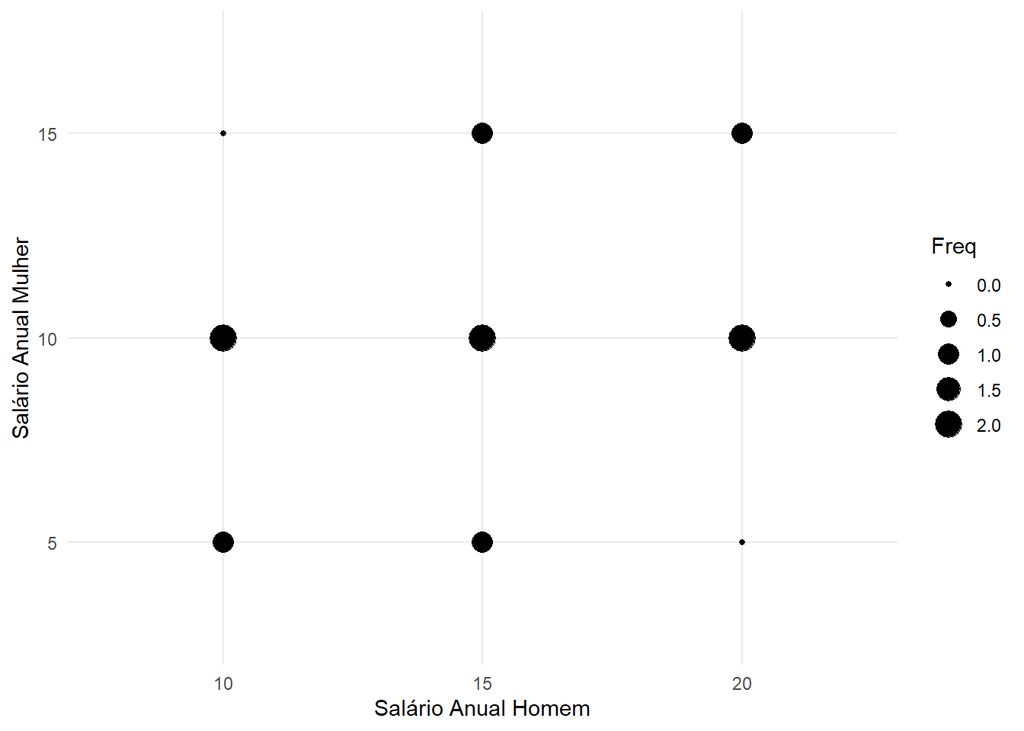

```r
ggplot(data.frame(table(data.ex29$Homem,data.ex29$Mulher)),aes(x=Var1,y=Var2,size=Freq)) + geom_point(fill="steelblue") + theme_minimal() + xlab("Salário Anual Homem") + ylab("Salário Anual Mulher")
```

4. Encontre a correlação entre o salário anual dos homens e o das mulheres.

```r
correlation.ex29 <- sum((data.ex29$Homem-salMedHom)*(data.ex29$Mulher-salMedMul))/(length(data.ex29$Homem)*salDesvPadHom*salDesvPadMul)
correlation.ex29
```

```
## [1] 0.4082483
```

5. Qual o salário médio familiar? E a variância do salário familiar?

```r
salMedFam <- mean(data.ex29$Homem+data.ex29$Mulher)
salDesvPadFam <- ((length(data.ex29$Mulher)-1)/length(data.ex29$Mulher))*var(data.ex29$Homem+data.ex29$Mulher)
data.ex29.e <- c(salMedFam,salDesvPadFam)
names(data.ex29.e) <- c("Salário anual médio","Variância")
data.ex29.e
```

```
## Salário anual médio           Variância
##                  25                  35
```

6. Se o homem é descontado em $8%$ e a mulher em $6%$, qual o salário líquido anual médio familiar? E a variância?

```r
salMedFamDes <- mean(0.92*data.ex29$Homem+0.94*data.ex29$Mulher)
salDesvPadFamDes <- ((length(data.ex29$Mulher)-1)/length(data.ex29$Mulher))*var(0.92*data.ex29$Homem+0.94*data.ex29$Mulher)
data.ex29.f <- c(salMedFamDes,salDesvPadFamDes)
names(data.ex29.f) <- c("Salário anual médio","Variância")
data.ex29.f
```

```
## Salário anual médio           Variância
##               23.20               30.18
```

## Ex. 30

O departamento de vendas de certa companhia foi formado há um ano com a admissão de 15 vendedores. Nessa época, foram observados para cada um dos vendedores os valores de três variáveis:

T: resultado em um teste apropriado para vendedores; E: anos de experiência de vendas; G: conceito do gerente de venda, quanto ao currículo do candidato. O diretor da companhia resolveu agora ampliar o quadro de vendedores e pede sua colaboração para responder a algumas perguntas. Para isso, ele lhe dá informações adicionais sobre duas variáveis: V: volume médio mensal de vendas em s.m.; Z: zona da capital para a qual o vendedor foi designado. O quadro de resultados é o seguinte:

```r
data.ex30 <- data.frame("Vendedor" = 1:15,
                        "T" = c(8,9,7,8,6,8,5,5,6,7,4,7,3,5,3),
                        "E" = c(5,2,2,1,4,4,3,3,1,3,4,2,3,1,2),
                        "G" = c("Bom","Bom","Mau","Mau","Bom","Bom","Bom","Bom","Mau","Mau","Bom","Mau","Mau","Mau","Bom"),
                        "V" = c(54,50,48,32,30,30,29,27,24,24,24,23,21,21,16),
                        "Z" = c("Norte","Sul","Sul","Oeste","Sul","Oeste","Norte","Norte","Oeste","Oeste","Sul","Norte","Sul","Oeste","Norte"))
data.ex30
```

```
##    Vendedor T E   G  V     Z
## 1         1 8 5 Bom 54 Norte
## 2         2 9 2 Bom 50   Sul
## 3         3 7 2 Mau 48   Sul
## 4         4 8 1 Mau 32 Oeste
## 5         5 6 4 Bom 30   Sul
## 6         6 8 4 Bom 30 Oeste
## 7         7 5 3 Bom 29 Norte
## 8         8 5 3 Bom 27 Norte
## 9         9 6 1 Mau 24 Oeste
## 10       10 7 3 Mau 24 Oeste
## 11       11 4 4 Bom 24   Sul
## 12       12 7 2 Mau 23 Norte
## 13       13 3 3 Mau 21   Sul
## 14       14 5 1 Mau 21 Oeste
## 15       15 3 2 Bom 16 Norte
```

Mais especificamente, o diretor lhe pede que responda aos sete itens seguintes:

1. Faça o histograma da variável V em classes de 10, tendo por limite inferior da primeira classe o valor 15.

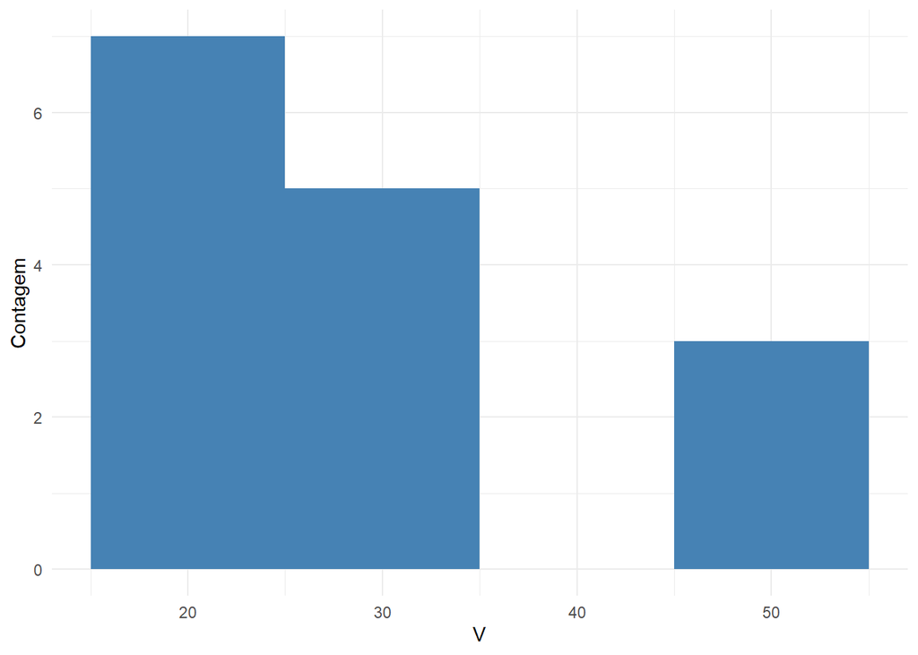

```r
ggplot(data.ex30,aes(x=V)) + geom_histogram(fill='steelblue',breaks=seq(15,max(data.ex30$V)+10,10)) + theme_minimal() + ylab("Contagem")
```

2. Encontre a média e a variância da variável V. Suponha que um vendedor seja considerado excepcional se seu volume de vendas é dois desvios padrões superior à média geral. Quantos vendedores excepcionais existem na amostra?

```r
data.ex30b <- c(mean(data.ex30$V),(((length(data.ex30$V)-1)/length(data.ex30$V))*var(data.ex30$V))^(1/2))
names(data.ex30b) <- c("Média","Desvio Padrão")
data.ex30b
```

```
##         Média Desvio Padrão
##      30.20000      11.04053
```

```r
data.ex30$V[data.ex30$V>(data.ex30b[1]+2*data.ex30b[2])]
```

```
## [1] 54
```

Apenas um vendedor!

3. O diretor de vendas anunciou que transferirá para outra praça todos os vendedores cujo volume de vendas for inferior ao 1o quartil da distribuição. Qual o volume mínimo de vendas que um vendedor deve realizar para não ser transferido?

```r
quantile(data.ex30$V,0.25)
```

```
##  25%
## 23.5
```

4. Os vendedores argumentam com o diretor que esse critério não é justo, pois há zonas de venda privilegiadas. A quem você daria razão?

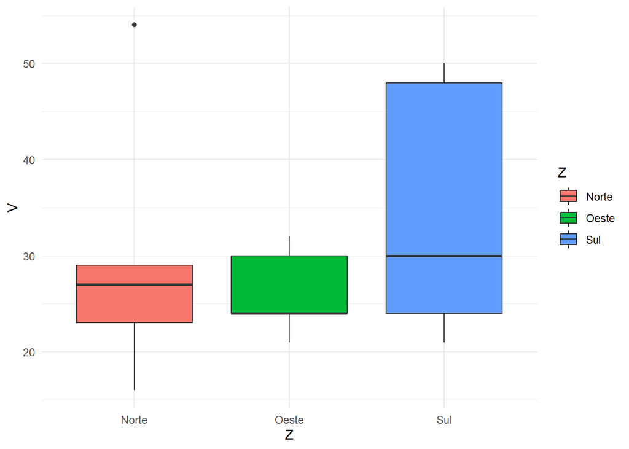

```r
ggplot(data.ex30,aes(x=Z,y=V,fill=Z)) + geom_boxplot() + theme_minimal()
```

5. Qual das três variáveis observadas na admissão do pessoal é mais importante para julgar um futuro candidato ao emprego?

Resultado no teste apropriado para vendedores.

6. Qual o grau de associabilidade entre o conceito do gerente e a zona a que o vendedor foi designado? Você tem explicação para esse resultado?

```r
matriz.ex30f <- matrix(nrow = 2,ncol = 3)
colnames(matriz.ex30f) <- c("Norte","Sul","Oeste")
rownames(matriz.ex30f) <- c("Bom","Mau")
matriz.ex30f[1,1] <- sum(data.ex30$G[data.ex30$Z == "Norte"]=="Bom")
matriz.ex30f[2,1] <- sum(data.ex30$G[data.ex30$Z == "Norte"]=="Mau")
matriz.ex30f[1,2] <- sum(data.ex30$G[data.ex30$Z == "Sul"]=="Bom")
matriz.ex30f[2,2] <- sum(data.ex30$G[data.ex30$Z == "Sul"]=="Mau")
matriz.ex30f[1,3] <- sum(data.ex30$G[data.ex30$Z == "Oeste"]=="Bom")
matriz.ex30f[2,3] <- sum(data.ex30$G[data.ex30$Z == "Oeste"]=="Mau")
chisquare.ex30f <- chisq.test(matriz.ex30f[1:2,1:3])$statistic
C.ex30f <- (chisquare/(chisquare+sum(matriz.ex30f)))^(1/2)
names(C.ex30f) <- "C"
C.ex30f
```

```
##        C
## 0.693403
```

7. Qual o grau de associação entre o conceito do gerente e o resultado do teste? E entre zona e vendas?

```r
#Realizando o teste do R^2 para cada associação
varp <- function(x) {return(((length(x)-1)/length(x))*var(x))}

#Entre gerente e resultado do teste
varAmo.1 <- varp(data.ex30$T)
varMed.1 <- (sum(data.ex30$G=="Bom")*varp(data.ex30$T[data.ex30$G=="Bom"])+sum(data.ex30$G=="Mau")*varp(data.ex30$T[data.ex30$G=="Mau"]))/(length(data.ex30$G[data.ex30$G=="Bom"])+length(data.ex30$G[data.ex30$G=="Mau"]))
R2.1 <- 1 - varMed.1/varAmo.1
R2.1
```

```
## [1] 0.001557026
```

Como o $R^2 = 0.001557$, podemos percebeu que o grau de associação entre o conceito do gerente e o resultado do teste é extremamente baixo.

```r
#Entre zona e vendas
varAmo.2 <- varp(data.ex30$V)
varMed.2 <- ((sum(data.ex30$Z=="Norte")*varp(data.ex30$V[data.ex30$Z=="Norte"]))+(sum(data.ex30$Z=="Oeste")*varp(data.ex30$V[data.ex30$Z=="Oeste"]))+(sum(data.ex30$Z=="Sul")*varp(data.ex30$V[data.ex30$Z=="Sul"])))/(sum(data.ex30$Z=="Norte")+sum(data.ex30$Z=="Oeste")+sum(data.ex30$Z=="Sul"))
R2.2 <- 1 - varMed.2/varAmo.2
R2.2
```

```
## [1] 0.09713411
```

Apesar de o $R^2 = 0.097134$, ele usa como medida apenas a variância dos dados. Portanto, como verificamos na questão $d$ as faixas de valores, na zona Sul temos vendas mais altas do que outras regiões.